# Exploring the openSenseMap Dataset

Norwin Roosen

2023-03-08

This package provides data ingestion functions for almost any data stored on the open data platform for environmental sensordata https://opensensemap.org. Its main goals are to provide means for:

- big data analysis of the measurements stored on the platform
- sensor metadata analysis (sensor counts, spatial distribution, temporal trends)

### Exploring the dataset

Before we look at actual observations, lets get a grasp of the openSenseMap datasets’ structure.

```r
library(magrittr)
library(opensensmapr)

# all_sensors = osem_boxes(cache = '.')
all_sensors = readRDS('boxes_precomputed.rds')  # read precomputed file to save resources
```

```r
summary(all_sensors)
```

```
## boxes total: 11390
##
## boxes by exposure:
##  indoor  mobile outdoor unknown
##    2364     590    8417      19
##
## boxes by model:
##                   custom          hackair_home_v2             homeEthernet
##                     2800                       73                       73
##    homeEthernetFeinstaub           homeV2Ethernet  homeV2EthernetFeinstaub
##                       55                       21                       40
##               homeV2Lora               homeV2Wifi      homeV2WifiFeinstaub
##                      240                      577                      743
##                 homeWifi        homeWifiFeinstaub        luftdaten_pms1003
##                      215                      222                        9
## luftdaten_pms1003_bme280        luftdaten_pms3003 luftdaten_pms3003_bme280
##                       10                        1                        7
##        luftdaten_pms5003 luftdaten_pms5003_bme280        luftdaten_pms7003
##                        7                       60                        6
## luftdaten_pms7003_bme280         luftdaten_sds011  luftdaten_sds011_bme280
##                       78                      286                     3066
##  luftdaten_sds011_bmp180   luftdaten_sds011_dht11   luftdaten_sds011_dht22
##                      114                      135                     2552
##
## $last_measurement_within
##    1h    1d   30d  365d never
##     0     0  4151  5909  2062
##
## oldest box: 2016-08-09 19:34:42 (OBS Bohmte UK_02)
## newest box: 2023-02-28 09:47:17 (bitburg)
##
## sensors per box:
##    Min. 1st Qu.  Median    Mean 3rd Qu.    Max.
##   1.000   4.000   5.000   4.994   5.000  76.000
```

Another feature of interest is the spatial distribution of the boxes: `plot()` can help us out here. This function requires a bunch of optional dependencies though.

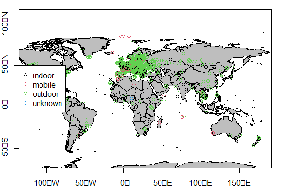

```r
plot(all_sensors)
```

It seems we have to reduce our area of interest to Germany.

But what do these sensor stations actually measure? Lets find out. `osem_phenomena()` gives us a named list of of the counts of each observed phenomenon for the given set of sensor stations:

```r
phenoms = osem_phenomena(all_sensors)
str(phenoms)
```

```
## List of 3298
##  $ Temperatur                                                   : int 9405
##  $ rel. Luftfeuchte                                             : int 8315
##  $ PM10                                                         : int 8148
##  $ PM2.5                                                        : int 8136
##  $ Luftdruck                                                    : int 5668
##  $ Beleuchtungsstärke                                           : int 1670
##  $ UV-Intensität                                                : int 1660
##  $ Temperature                                                  : int 644
##  $ Humidity                                                     : int 473
##  $ VOC                                                          : int 423
##  $ Luftfeuchte                                                  : int 363
##  $ Lufttemperatur                                               : int 357
##  $ CO₂                                                          : int 305
##  $ Pressure                                                     : int 293
```

[output cut: 86 more lines]

Thats quite some noise there, with many phenomena being measured by a single sensor only, or many duplicated phenomena due to slightly different spellings. We should clean that up, but for now let’s just filter out the noise and find those phenomena with high sensor numbers:

```r
phenoms[phenoms > 20]
```

```
## $Temperatur
## [1] 9405
##
## $`rel. Luftfeuchte`
## [1] 8315
##
## $PM10
## [1] 8148
##
## $PM2.5
## [1] 8136
##
## $Luftdruck
## [1] 5668
##
## $Beleuchtungsstärke
## [1] 1670
##
## $`UV-Intensität`
## [1] 1660
##
## $Temperature
## [1] 644
##
## $Humidity
## [1] 473
##
## $VOC
## [1] 423
##
## $Luftfeuchte
## [1] 363
##
## $Lufttemperatur
## [1] 357
##
## $`CO₂`
## [1] 305
##
## $Pressure
```

[output cut: 181 more lines]

```
##
## $Regenrate
## [1] 26
##
## $`CO2 Konzentration`
## [1] 25
##
## $RSSI
## [1] 22
##
## $`gefühlte Temperatur`
## [1] 22
##
## $`PM 2.5`
## [1] 21
```

Alright, temperature it is! Fine particulate matter (PM2.5) seems to be more interesting to analyze though. We should check how many sensor stations provide useful data: We want only those boxes with a PM2.5 sensor, that are placed outdoors and are currently submitting measurements:

```r
pm25_sensors = osem_boxes(
  exposure = 'outdoor',
  date = Sys.time(), # ±4 hours
  phenomenon = 'PM2.5'
)
```

```r
pm25_sensors = readRDS('pm25_sensors.rds') # read precomputed file to save resources

summary(pm25_sensors)
```

```
## boxes total: 3011
##
## boxes by exposure:
## outdoor
##    3011
##
## boxes by model:
##                   custom          hackair_home_v2    homeEthernetFeinstaub
##                      175                        8                       12
##  homeV2EthernetFeinstaub               homeV2Lora               homeV2Wifi
##                        9                       22                        2
##      homeV2WifiFeinstaub                 homeWifi        homeWifiFeinstaub
##                      132                        3                       32
##        luftdaten_pms1003 luftdaten_pms1003_bme280        luftdaten_pms5003
##                        1                        3                        3
## luftdaten_pms5003_bme280        luftdaten_pms7003 luftdaten_pms7003_bme280
##                       10                        2                       28
##         luftdaten_sds011  luftdaten_sds011_bme280  luftdaten_sds011_bmp180
##                      117                     1365                       60
##   luftdaten_sds011_dht11   luftdaten_sds011_dht22
##                       44                      983
##
## $last_measurement_within
##    1h    1d   30d  365d never
##     0     0  3011  3011     0
##
## oldest box: 2017-03-03 18:20:43 (Witten Heven Dorf)
## newest box: 2023-02-28 08:28:27 (eth0)
##
## sensors per box:
##    Min. 1st Qu.  Median    Mean 3rd Qu.    Max.
##   2.000   4.000   5.000   4.854   5.000  26.000
```

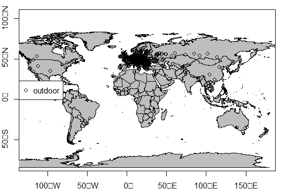

```r
plot(pm25_sensors)
```

Thats still more than 200 measuring stations, we can work with that.

### Analyzing sensor data

Having analyzed the available data sources, let’s finally get some measurements. We could call `osem_measurements(pm25_sensors)` now, however we are focusing on a restricted area of interest, the city of Berlin. Luckily we can get the measurements filtered by a bounding box:

```r
library(sf)
library(units)
library(lubridate)
library(dplyr)
```

Since the API takes quite long to response measurements, especially filtered on space and time, we do not run the following chunks for publication of the package on CRAN.

```r
# construct a bounding box: 12 kilometers around Berlin
berlin = st_point(c(13.4034, 52.5120)) %>%
  st_sfc(crs = 4326) %>%
  st_transform(3857) %>% # allow setting a buffer in meters
  st_buffer(set_units(12, km)) %>%
  st_transform(4326) %>% # the opensensemap expects WGS 84
  st_bbox()
pm25 = osem_measurements(
  berlin,
  phenomenon = 'PM2.5',
  from = now() - days(3), # defaults to 2 days
  to = now()
)
```

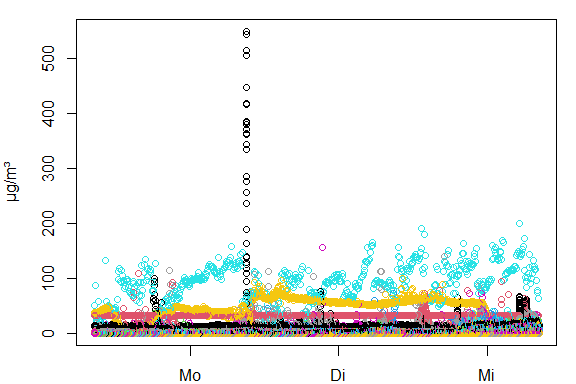

```r
pm25 = readRDS('pm25_berlin.rds') # read precomputed file to save resources
plot(pm25)
```

Now we can get started with actual spatiotemporal data analysis. First, lets mask the seemingly uncalibrated sensors:

```r
outliers = filter(pm25, value > 100)$sensorId
bad_sensors = outliers[, drop = TRUE] %>% levels()

pm25 = mutate(pm25, invalid = sensorId %in% bad_sensors)
```

Then plot the measuring locations, flagging the outliers:

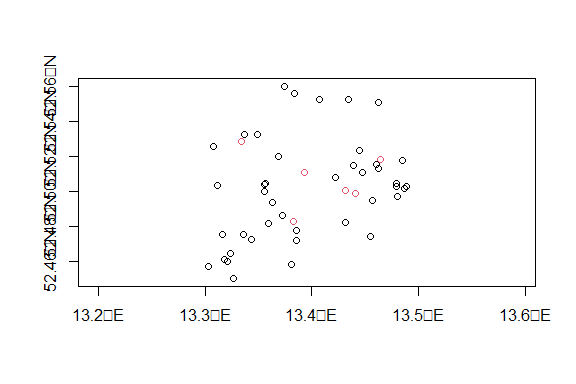

```r
st_as_sf(pm25) %>% st_geometry() %>% plot(col = factor(pm25$invalid), axes = TRUE)
```

Removing these sensors yields a nicer time series plot:

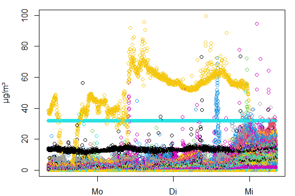

```r
pm25 %>% filter(invalid == FALSE) %>% plot()
```